# My solution to Bernhard’s project

15/01/23

Among other things, the cycling of elements (e.g. Nitrogen) is being investigated between plots with high plant diversity and plots with low plant diversity.

The following work deals with the influence of the number of different legumes and plant species on the availability of mineralic Nitrogen (Nmin) in soil.

## The original data

The following experimental data is imported:

| plotcode | Mixcode | Block | plot | Orientation | NO3--N [mg/kg] | NH4+-N [mg/kg] | Nmin [mg/kg] | SWC [%] | sowndiv | funcgr | numgras | numsherb | numtherb | numleg | grass | sherb | therb | leg | Achmil | Ajurep | Alopra | Antodo | Antsyl | Arrela | Avepub | Belper | Broere | Brohor | Campat | … |
| --- | --- | --- | --- | --- | --- | --- | --- | --- | --- | --- | --- | --- | --- | --- | --- | --- | --- | --- | --- | --- | --- | --- | --- | --- | --- | --- | --- | --- | --- | --- |
| B1A02 | S08M07 | B1 | A02 | NO | 1.843586 | 1.0377801 | 2.881366 | 21.359 | 8 | 2 | 4 | 0 | 4 | 0 | 1 | 0 | 1 | 0 | 0 | 0 | 1 | 0 | 0 | 0 | 0 | 0 | 1 | 0 | 0 | … |
| B1A03 | S08M11 | B1 | A03 | SO | 1.587877 | 0.5292922 | 2.117169 | 21.256 | 8 | 3 | 3 | 3 | 0 | 2 | 1 | 1 | 0 | 1 | 0 | 0 | 0 | 0 | 0 | 0 | 0 | 0 | 0 | 0 | 0 | … |
| B1A04 | S04M16 | B1 | A04 | NO | 1.703704 | 0.5061728 | 2.209877 | 23.457 | 4 | 4 | 1 | 1 | 1 | 1 | 1 | 1 | 1 | 1 | 0 | 0 | 0 | 0 | 0 | 0 | 0 | 0 | 0 | 0 | 1 | … |
| B1A05 | S02M07 | B1 | A05 | SO | 1.336845 | 0.1856729 | 1.522517 | 23.039 | 2 | 1 | 0 | 0 | 0 | 2 | 0 | 0 | 0 | 1 | 0 | 0 | 0 | 0 | 0 | 0 | 0 | 0 | 0 | 0 | 0 | … |
| B1A06 | S16M03 | B1 | A06 | NO | 1.507145 | 0.2818239 | 1.788969 | 23.267 | 16 | 2 | 8 | 0 | 8 | 0 | 1 | 0 | 1 | 0 | 1 | 0 | 1 | 1 | 1 | 0 | 1 | 0 | 0 | 1 | 1 | … |
| B1A07 | S02M06 | B1 | A07 | SO | 2.959211 | 0.3880933 | 3.347305 | 22.249 | 2 | 1 | 0 | 0 | 2 | 0 | 0 | 0 | 1 | 0 | 0 | 0 | 0 | 0 | 0 | 0 | 0 | 0 | 0 | 0 | 0 | … |
| B1A08 | S01M16 | B1 | A08 | NO | 2.806864 | 0.5157912 | 3.322655 | 19.712 | 1 | 1 | 0 | 0 | 0 | 1 | 0 | 0 | 0 | 1 | 0 | 0 | 0 | 0 | 0 | 0 | 0 | 0 | 0 | 0 | 0 | … |
| B1A09 | S01M01 | B1 | A09 | SO | 2.107820 | 0.2095494 | 2.317370 | 22.525 | 1 | 1 | 1 | 0 | 0 | 0 | 1 | 0 | 0 | 0 | 0 | 0 | 0 | 0 | 0 | 0 | 0 | 0 | 0 | 0 | 0 | … |
| B1A11 | S16M14 | B1 | A11 | SO | 3.604724 | 0.5685302 | 4.173254 | 20.238 | 16 | 1 | 0 | 0 | 16 | 0 | 0 | 0 | 1 | 0 | 1 | 0 | 0 | 0 | 1 | 0 | 0 | 0 | 0 | 0 | 1 | … |
| B1A12 | S08M04 | B1 | A12 | SW | 4.694509 | 0.5047859 | 5.199295 | 26.196 | 8 | 1 | 0 | 0 | 0 | 8 | 0 | 0 | 0 | 1 | 0 | 0 | 0 | 0 | 0 | 0 | 0 | 0 | 0 | 0 | 0 | … |

[output cut: 67 more lines]

The data is modified by selecting the relevant columns and introducing groups as suggested in the project description.  
Additionally, the data is grouped by the number of legumes as well as the number of different plant species.  
After grouping, the mean of Nmin (mass fraction of mineralic Nitrogen) as well as the standard error is calculated.

## The modified data

| Nmin | sowndiv | numleg | sowndiv_factor | numleg_factor | rec_sowndiv | rec_numleg | Nmin_mean | se | count |
| --- | --- | --- | --- | --- | --- | --- | --- | --- | --- |
| 2.881366 | 8 | 0 | 8 | 0 | 8-16 | 0-1 | 2.946128 | 0.3184067 | 11 |
| 2.117169 | 8 | 2 | 8 | 2 | 8-16 | 2-3 | 3.768627 | 0.9979235 | 6 |
| 2.209877 | 4 | 1 | 4 | 1 | 2-4 | 0-1 | 3.562668 | 0.4460857 | 24 |
| 1.522517 | 2 | 2 | 2 | 2 | 2-4 | 2-3 | 2.935640 | 0.4728705 | 4 |
| 1.788969 | 16 | 0 | 16 | 0 | 8-16 | 0-1 | 2.946128 | 0.3184067 | 11 |
| 3.347305 | 2 | 0 | 2 | 0 | 2-4 | 0-1 | 3.562668 | 0.4460857 | 24 |
| 3.322655 | 1 | 1 | 1 | 1 | 0-1 | 0-1 | 4.230983 | 1.0794108 | 16 |
| 2.317370 | 1 | 0 | 1 | 0 | 0-1 | 0-1 | 4.230983 | 1.0794108 | 16 |
| 4.173254 | 16 | 0 | 16 | 0 | 8-16 | 0-1 | 2.946128 | 0.3184067 | 11 |
| 5.199295 | 8 | 8 | 8 | 8 | 8-16 | 6-8 | 7.133537 | 1.2977052 | 4 |

[output cut: 67 more lines]

## The Plot

Regarding the visualization, determining trends in changes of Nmin in relation to increasing biodiversity is not easy, however it does not seem as if an increasing diversity level and a higher number of legumes are negatively affecting the availability of mineralic Nitrogen in the soil.

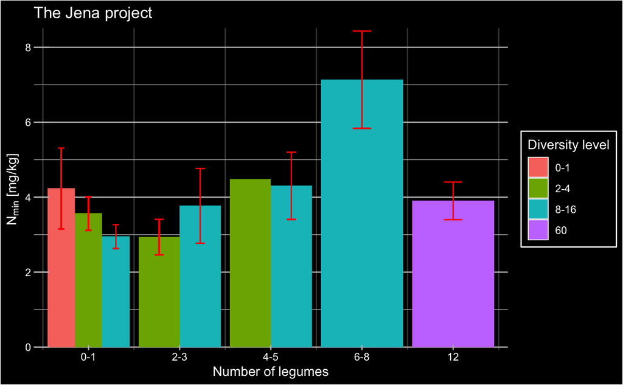